# Which Democratic candidates are getting mentioned the most on cable and online news?

Tanner Gildea

2019-07-18

FiveThirtyEight is currently running an [interesting series](https://fivethirtyeight.com/tag/media/) analyzing how cable news and online media sources are covering the Democratic presidential candidates. [Dhrumil Mehta](https://fivethirtyeight.com/contributors/dhrumil-mehta/), one of FiveThirtyEight’s data journalists, has diligently kept track of how coverage of individual candidates has risen and fallen week to week. They have also kindly shared the underlying data [here](https://github.com/fivethirtyeight/data/tree/master/media-mentions-2020).

Personally, I was interested in seeing how coverage of the top candidates has changed since the beginning of the race (roughly January of 2019). I also wanted to see if coverage of candidates diverged based on media type - cable or online.

The graph below helps answer these two questions.

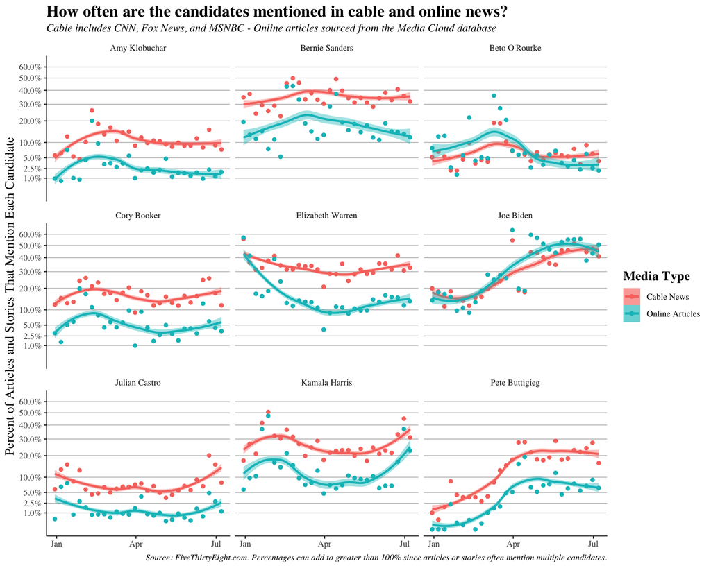

You can see that for some candidates, e.g. Joe Biden or Beto O’Rourke, cable news and online media coverage tracks relatively closely. Coverage diverges more sharply for other candidates, such as Elizabeth Warren, Bernie Sanders, or Pete Buttigieg.

It’s important to note that in this race, all news is NOT good news. FiveThirtyEight’s dataset only tracks total coverage, not sentiment - good or bad. And increased coverage invites additional scrutiny.

## Coverage Changes for All “Major” Candidates

According to FiveThirtyEight, there are currently 24 (er, 23, RIP Eric Swalwell) “major candidates” in the Democratic primary field. Although I think there is plenty of room for a distinction to be made between major and minor candidates, FiveThirtyEight uses this categorization to collect data on all of them.

So why not see how their coverage has changed?

**How much has coverage changed between January and now?**

January 6th to July 7th, 2019

[output not shown]

Source: Internet Archive's Television News Archive via the GDELT Project, Media Cloud, all via FiveThirtyEight.com  
Per FiveThirtyEight: “Includes all candidates that qualify as “major” in FiveThirtyEight’s rubric. Each network’s daily news coverage is chopped up into 15-second clips, and each clip that includes a candidate’s name is counted as one mention. For both cable and online news, our search queries look for an exact match for each candidate’s name, except for Julian Castro, for whom our search query is “Julian Castro” OR “Julián Castro”. Media Cloud searches use two of the database’s publication lists: “top online news” and “digital native” publications.”

Candidates who have won the largest increases in coverage include Joe Biden, Kamala Harris, and Pete Buttigieg (who was attracting literally no coverage back in January). Even though he has always attracted significant attention, Biden’s front-runner status has led him to dominate coverage since his presidential [campaign announcement](https://time.com/5553949/joe-biden-presidential-campaign-launch-announcement/) in late April.

Other major candidates have trended downwards in their coverage, Beto O’Rourke most precipitously. I would hesistate to read much into Warren’s staggering 28 point drop since January - she was the only major candidate announced at the time and was attracting nearly half of the media’s attention.

And for the rest of them? The haven’t reallymoved much.

## Post-Debate Bump?

The great part about FiveThirtyEight’s dataset is that it tracks coverage week to week, so you can isolate changes in coverage around specific events - for example, the first Democratic primary debates. Held over two nights June 26-27 in Miami, FL, the debates saw 20 candidates appear on stage.

Below is the change in cable and online coverage of candidates based on the news cycle prior to the debate (June 16-22) and the news cycle during and just after (June 23-29).

How did the first debates change candidate coverage?

June 16th to June 23rd, 2019

| Candidate | Cable Clips |  |  | Online Articles |  |  |
| --- | --- | --- | --- | --- | --- | --- |
|  | Before | After | Change | Before | After | Change |
| Amy Klobuchar | 0.9% | 2.3% | 1.3% | 8.2% | 15.5% | 7.3% |
| Andrew Yang | 1.0% | 0.9% | -0.1% | 4.1% | 9.8% | 5.6% |
| Bernie Sanders | 14.6% | 14.4% | -0.2% | 32.9% | 40.9% | 7.9% |
| Beto O'Rourke | 2.3% | 6.1% | 3.8% | 3.4% | 9.0% | 5.6% |
| Bill de Blasio | 1.2% | 2.3% | 1.1% | 9.0% | 15.2% | 6.2% |
| Cory Booker | 12.6% | 6.1% | -6.5% | 24.7% | 25.7% | 0.9% |
| Elizabeth Warren | 15.5% | 15.3% | -0.3% | 31.4% | 41.7% | 10.3% |
| Eric Swalwell | 0.8% | 1.7% | 0.9% | 4.4% | 12.2% | 7.8% |
| Jay Inslee | 0.7% | 1.5% | 0.9% | 4.4% | 11.9% | 7.5% |
| Joe Biden | 55.6% | 37.9% | -17.7% | 55.6% | 44.5% | -11.1% |
| Joe Sestak | 0.0% | 0.1% | 0.1% | 0.0% | 1.3% | 1.3% |
| John Delaney | 0.3% | 1.4% | 1.1% | 3.5% | 10.4% | 6.8% |
| John Hickenlooper | 0.5% | 0.7% | 0.2% | 4.1% | 8.3% | 4.2% |
| Julian Castro | 0.6% | 4.8% | 4.2% | 6.8% | 20.1% | 13.3% |
| Kamala Harris | 7.0% | 16.8% | 9.8% | 21.5% | 33.1% | 11.6% |
| Kirsten Gillibrand | 0.9% | 0.6% | -0.3% | 6.8% | 12.4% | 5.6% |
| Marianne Williamson | 0.2% | 1.2% | 1.0% | 3.9% | 12.1% | 8.2% |
| Michael Bennet | 0.4% | 0.7% | 0.4% | 3.5% | 8.4% | 4.9% |
| Mike Gravel | 0.0% | 0.0% | 0.0% | 1.2% | 1.0% | -0.1% |
| Pete Buttigieg | 5.5% | 6.9% | 1.4% | 22.0% | 24.3% | 2.3% |
| Seth Moulton | 0.2% | 0.1% | -0.0% | 3.0% | 2.5% | -0.6% |
| Steve Bullock | 0.4% | 0.4% | 0.0% | 3.6% | 2.2% | -1.4% |
| Tim Ryan | 1.2% | 1.8% | 0.6% | 3.3% | 10.4% | 7.0% |
| Tulsi Gabbard | 0.3% | 1.5% | 1.2% | 3.2% | 11.8% | 8.5% |

Source: Same as above.

You’ll notice that in cable television stories, Kamala Harris clearly had a burst of coverage. A larger pool of candidates received a post-debate bounce online - one that candidates such as Julian Castro badly needed. And some candidates should be worried, especially the single-digit candidates that are holding even or trending down.

I realized soon after constructing this table that Mehta had already published [an article](https://fivethirtyeight.com/features/media-outlets-paid-way-more-attention-to-kamala-harris-after-the-debate/) about the effects of the first debate on candidate coverage - makes sense, given this is their full-time job. Maybe I’ll beat them to it next time… the [next debates](https://www.cnn.com/politics/live-news/cnn-democratic-debate-draw/index.html) are set for July 30-31 in Detroit!